# 跟着iMeta学做图｜ComplexHeatmap绘制多样的热图

顾祖光(Zuguang Gu)

2022-09-20

如果你使用本代码，请引用： Zuguang Gu. 2022. Complex heatmap visualization. iMeta 1: e43. https://doi.org/10.1002/imt2.43

**翻译及注释：农心生信工作室**

热图（Heatmap）是矩阵类型数据最为常用的可视化方法，在生物学领域常用于各种组学数据的可视化，例如基因表达量数据、物种丰度分布、表观遗传信号数据等。现如今多组学数据不断涌现， 现有的R语言包例如 *gplots*、*pheatmap*、*ggplot2_绘制热图的功能较为单一，已无法满足大家从多个维度、对多类型数据更加充分可视化的需求。***ComplexHeatmap**_ 由德国国家肿瘤疾病中心顾顾祖光博士开发，该R包正如其名一样复杂，但是其绘制热图功能却堪称全面，下面我们将以顾祖光博士发表在iMeta上的方法论文[Complex heatmap visualization](https://onlinelibrary.wiley.com/doi/epdf/10.1002/imt2.43)

- [iMeta | 德国国家肿瘤中心顾祖光发表复杂热图(ComplexHeatmap)可视化方法](https://mp.weixin.qq.com/s/ncvGZ_ucxGPQZ84XkRiFuw)

本文对其中的Figure 2图A为例，对_**ComplexHeatmap**_的热图绘制方法进行讲解和探讨，先上原图：

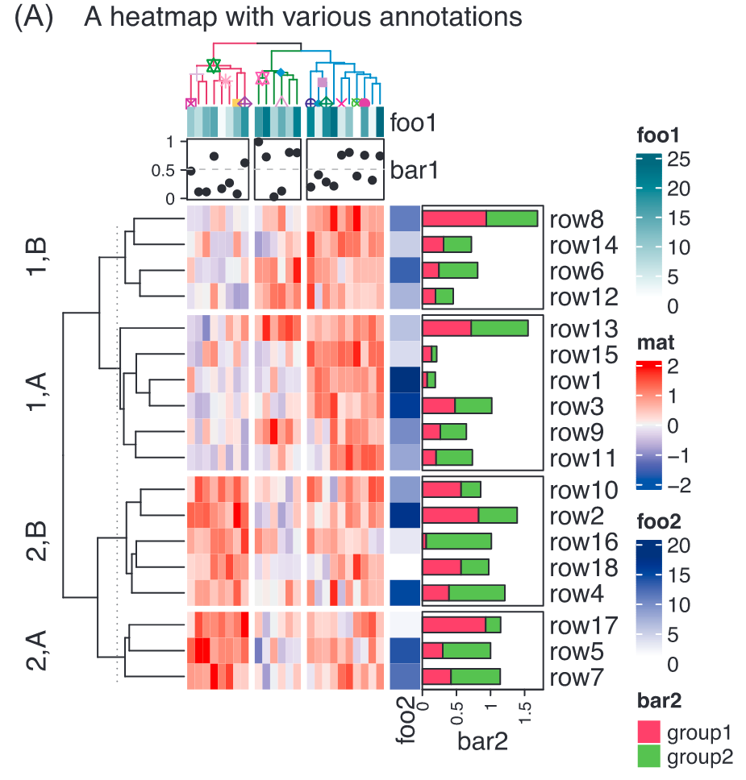

该热图原始数据是18 * 24的矩阵，行注释为堆叠柱状图、列注释为点图，行列分别进行了层次聚类。

代码、数据和结果下载，请访问 https://github.com/iMetaScience/iMetaPlot ，220919ComplexHeatmap 目录

### R包检测和安装

1. 先安装所_**ComplexHeatmap**_包及其依赖并将所有包载入

```r
# 检查开发者工具devtools，如没有则安装
if (!require("devtools"))
  install.packages("devtools")
# 加载开发者工具devtools
library(devtools)
# 检查热图包，没有则通过github安装最新版
if (!require("ComplexHeatmap"))
  install_github("jokergoo/ComplexHeatmap")
# ComplexHeatmap依赖关系
if (!require("circlize"))
  install_github("jokergoo/circlize")
# 用于绘制矩阵列方向上的层次聚类结果
if (!require("dendextend"))
  install.packages('dendextend')
# 加载包
library(ComplexHeatmap)
library(circlize)
library(dendextend)
```

### 生成测试数据

2. 设置随机种子并生成18 * 24的随机数据**mat**

```r
# 设置随机数种子，确保数据可重复
set.seed(123)
# 分小组，用于形成不同聚类簇
nr1 = 4; nr2 = 8; nr3 = 6; nr = nr1 + nr2 + nr3
nc1 = 6; nc2 = 8; nc3 = 10; nc = nc1 + nc2 + nc3
mat = cbind(rbind(matrix(rnorm(nr1*nc1, mean = 1,   sd = 0.5), nr = nr1),
                  matrix(rnorm(nr2*nc1, mean = 0,   sd = 0.5), nr = nr2),
                  matrix(rnorm(nr3*nc1, mean = 0,   sd = 0.5), nr = nr3)),
            rbind(matrix(rnorm(nr1*nc2, mean = 0,   sd = 0.5), nr = nr1),
                  matrix(rnorm(nr2*nc2, mean = 1,   sd = 0.5), nr = nr2),
                  matrix(rnorm(nr3*nc2, mean = 0,   sd = 0.5), nr = nr3)),
            rbind(matrix(rnorm(nr1*nc3, mean = 0.5, sd = 0.5), nr = nr1),
                  matrix(rnorm(nr2*nc3, mean = 0.5, sd = 0.5), nr = nr2),
                  matrix(rnorm(nr3*nc3, mean = 1,   sd = 0.5), nr = nr3))
)
dim(mat) #查看数据维度
```

```
#> [1] 18 24
```

```r
# 可选从文件读取矩阵
# write.table(mat, file="mat.txt", sep="\t", quote=F, row.names=T, col.names=T)
# mat = as.matrix(read.table(("mat.txt"), header=T, row.names=1, sep="\t", comment.char=""))

mat = mat[sample(nr, nr), sample(nc, nc)] # 打乱数据
rownames(mat) = paste0("row", seq_len(nr)) # 行命名
colnames(mat) = paste0("column", seq_len(nc)) # 列命名
```

### 热图预览

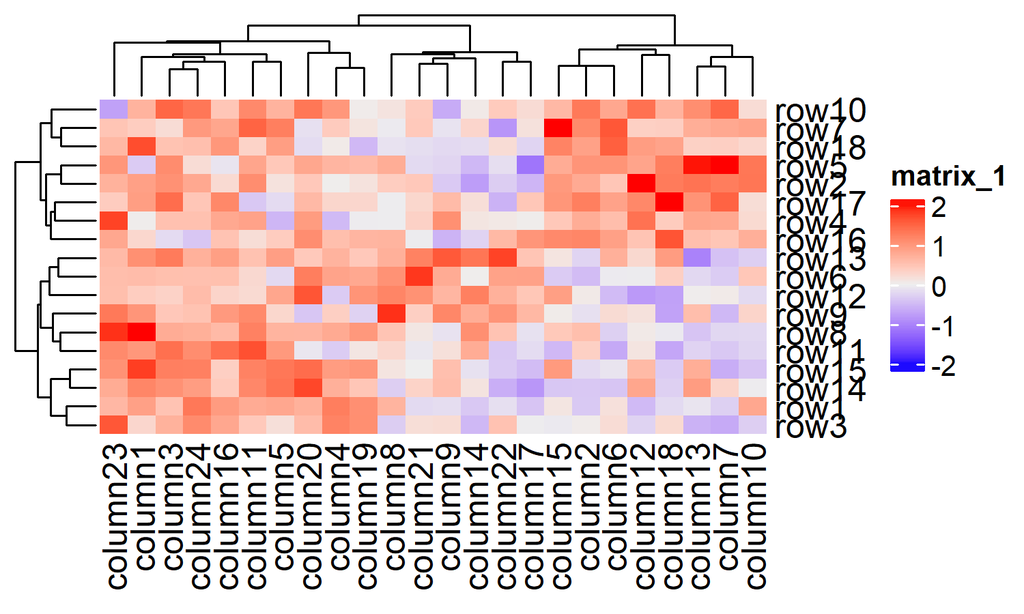

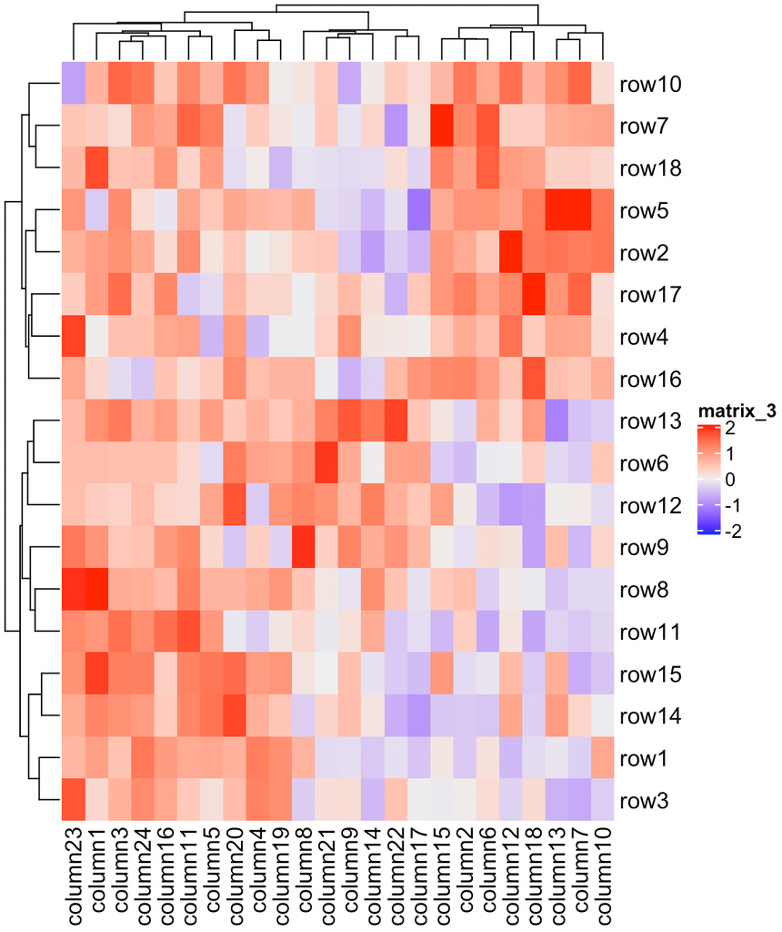

```r
Heatmap(mat)
```

### 热图聚类着色

4. 对列数据做层次聚类，**hclust()**函数做聚类时默认方法为’complete’即使用样本最大距离定义两个类之间的距离，采用欧式距离作为距离的度量，**color_branches()**用于给不同分支着色

```r
# 层次聚类
column_dend = as.dendrogram(hclust(dist(t(mat))))
# 分支着色
column_dend = color_branches(column_dend, k = 3)
```

5. 尝试一些参数的设置，由于*ComplexHeatmap*基于**grid**绘图框架，所以凡是量化长度的参数都需要用**unit()**函数制定，例如下面的**row_dend_width**。**cluster_columns**和**cluster_rows**参数可以指定聚类方法为我们前面设置好的**dendrogram**对象

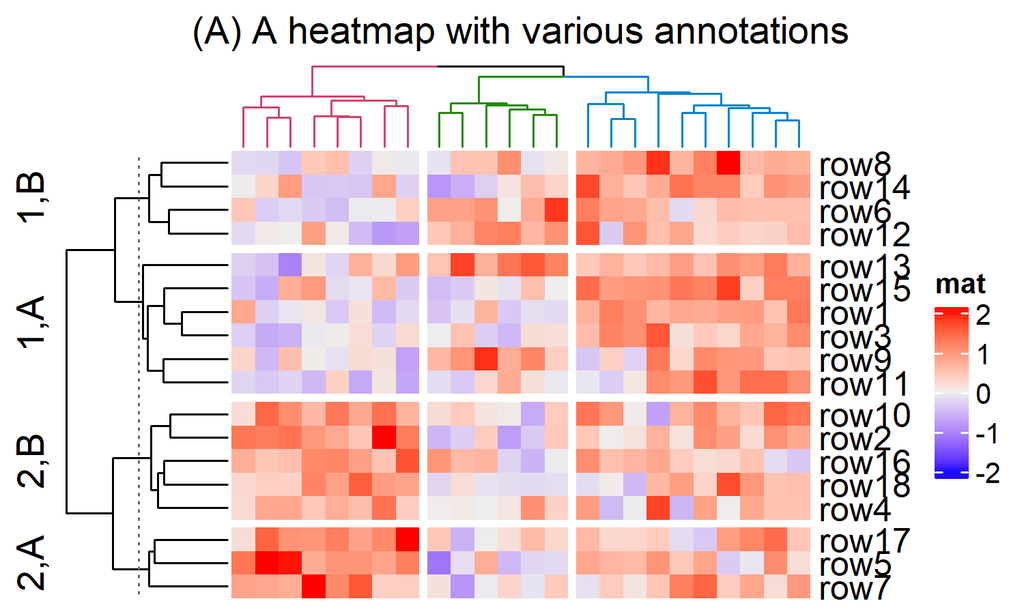

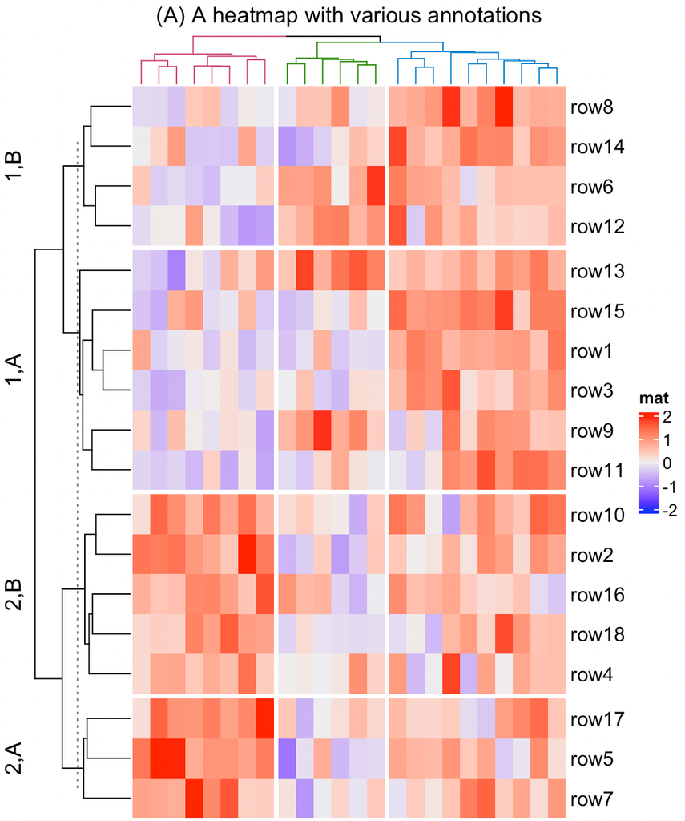

```r
Heatmap(mat, name = "mat",
        row_dend_width = unit(2, "cm"), # 行聚类树的宽度
        cluster_columns = column_dend, # 列聚类方法指定为前面设置的dendrogram对象
        column_title = "(A) A heatmap with various annotations", # 标题
        show_column_names = FALSE, # 不显示列名
        row_split = rep(c("A", "B"), 9), # 行分割后的命名
        row_km = 2, # 行k-means聚类的类别数
        column_split = 3  # 列分割数
        )
```

这里需要注意的是**row_km**参数，官方的解释如下： > Apply k-means clustering on rows. If the value is larger than 1, the heatmap will be split by rows according to the k-means clustering. For each row slice, hierarchical clustering is still applied with parameters above.

这就是说这个参数一旦指定一个大于1的数，就会先进行一个k-means聚类，然后在k个类别内用默认的层次聚类方法进行第二次聚类，同时，热图的行也会根据聚类结果切割开来

### 热图注释

6. 最后，再把行和列的annotation加上，**anno_points()用于**在矩阵上方绘制点图，数值为0-1之间的随机数；**anno_barplot()用于**在矩阵右边绘制堆叠柱状图，图中颜色属性用**grid**框架中的**gpar()**函数控制

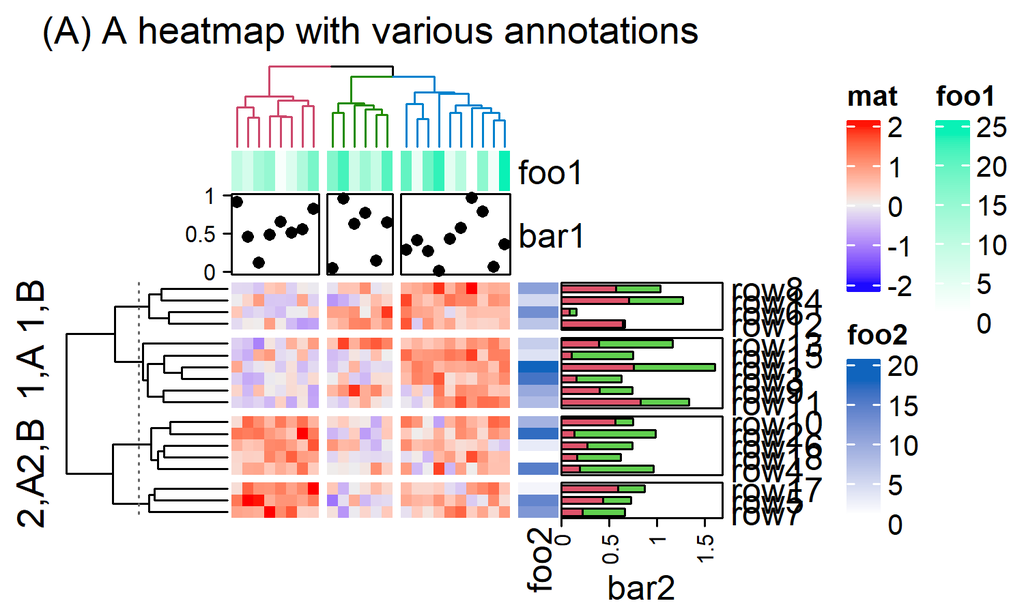

```r
(ht = Heatmap(mat, name = "mat",
        row_dend_width = unit(2, "cm"), # 行聚类树的宽度
        cluster_columns = column_dend, # 列聚类方法指定为前面设置的dendrogram对象
        column_title = "(A) A heatmap with various annotations", # 标题
        show_column_names = FALSE, # 不显示列名
        row_split = rep(c("A", "B"), 9), # 行分割后的命名
        row_km = 2, # 行k-means聚类的类别数
        column_split = 3,  # 列分割数
        top_annotation = HeatmapAnnotation(foo1 = 1:24,
                                           bar1 = anno_points(runif(24))),
        right_annotation = rowAnnotation(foo2 = 18:1,
                                         bar2 = anno_barplot(cbind(runif(18),
                                                                   runif(18)),
                                                        gp = gpar(fill = 2:3),
                                                        width = unit(2, "cm")))
        ))
```

[figure not shown]

```r
# 保存图为PDF，指定宽和高
pdf("Figure2A.pdf", width = 8, height = 4.5)
print(ht)
dev.off()
```

### 附.完整代码

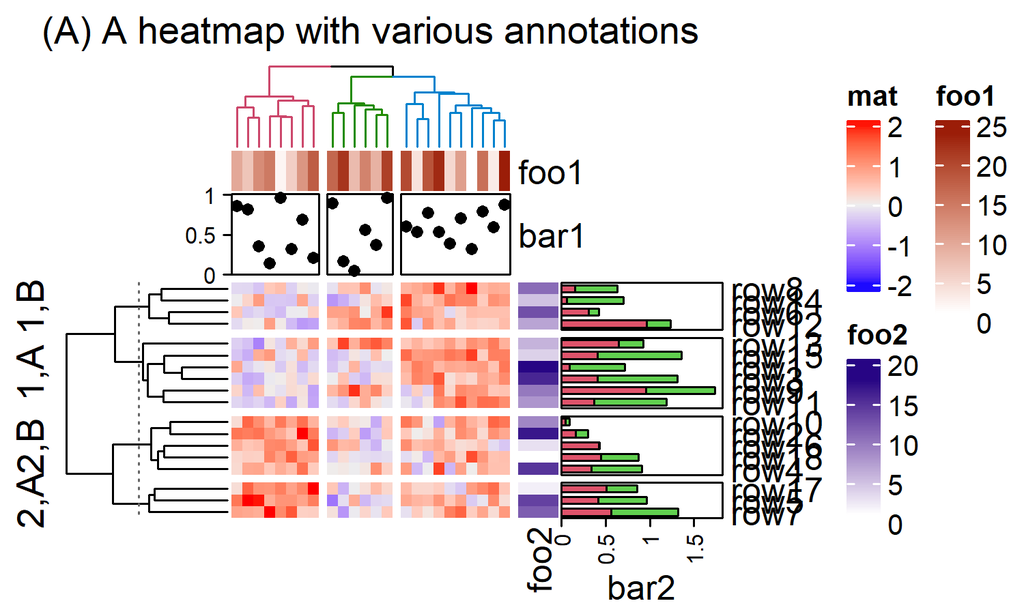

```r
library(ComplexHeatmap)
library(circlize)
library(dendextend)

set.seed(123)
nr1 = 4; nr2 = 8; nr3 = 6; nr = nr1 + nr2 + nr3
nc1 = 6; nc2 = 8; nc3 = 10; nc = nc1 + nc2 + nc3
mat = cbind(rbind(matrix(rnorm(nr1*nc1, mean = 1,   sd = 0.5), nr = nr1),
                  matrix(rnorm(nr2*nc1, mean = 0,   sd = 0.5), nr = nr2),
                  matrix(rnorm(nr3*nc1, mean = 0,   sd = 0.5), nr = nr3)),
            rbind(matrix(rnorm(nr1*nc2, mean = 0,   sd = 0.5), nr = nr1),
                  matrix(rnorm(nr2*nc2, mean = 1,   sd = 0.5), nr = nr2),
                  matrix(rnorm(nr3*nc2, mean = 0,   sd = 0.5), nr = nr3)),
            rbind(matrix(rnorm(nr1*nc3, mean = 0.5, sd = 0.5), nr = nr1),
                  matrix(rnorm(nr2*nc3, mean = 0.5, sd = 0.5), nr = nr2),
                  matrix(rnorm(nr3*nc3, mean = 1,   sd = 0.5), nr = nr3))
)

mat = mat[sample(nr, nr), sample(nc, nc)] # random shuffle rows and columns
rownames(mat) = paste0("row", seq_len(nr))
colnames(mat) = paste0("column", seq_len(nc))

column_dend = as.dendrogram(hclust(dist(t(mat))))
column_dend = color_branches(column_dend, k = 3) # `color_branches()` returns a dendrogram object

Heatmap(mat, name = "mat",
        row_dend_width = unit(2, "cm"), # 行聚类树的宽度
        cluster_columns = column_dend, # 列聚类方法指定为前面设置的dendrogram对象
        column_title = "(A) A heatmap with various annotations", # 标题
        show_column_names = FALSE, # 不显示列名
        row_split = rep(c("A", "B"), 9), # 行分割后的命名
        row_km = 2, # 行k-means聚类的类别数
        column_split = 3,  # 列分割数
        top_annotation = HeatmapAnnotation(foo1 = 1:24,
                                           bar1 = anno_points(runif(24))),
        right_annotation = rowAnnotation(foo2 = 18:1,
                                         bar2 = anno_barplot(cbind(runif(18),
                                                                   runif(18)),
                                                        gp = gpar(fill = 2:3),
                                                        width = unit(2, "cm")))
        )
```

以上代码来自Zuguang Gu博士的githubhttps://github.com/jokergoo/ComplexHeatmap_v2_paper_code，论文中其他的图都有相应的代码实现，大家可以参考学习，绘制出更加漂亮的热图！